# Homework 2

# Question 1

## Loading R Packages

```r
library(magrittr)
library(dplyr)
library(ggpubr)
library(readr)
library(tidyverse)
```

```r
library(scatterplot3d)
library(ggplot2)
```

## Importing the distance data

```r
distances <- read.csv(file = "C:/Users/Gaye/Desktop/ETM58D - Business Analytics/HW2_q1_data.csv")
head(distances)
```

```
##   ADANA ADIYAMAN AFYON AĞRI AMASYA ANKARA ANTALYA ARTVİN AYDIN BALIKESİR
## 1    NA      336   573  966    611    490     557   1034   883       901
## 2   336       NA   909  646    632    755     893    755  1219      1237
## 3   573      909    NA 1310    589    256     292   1237   346       328
## 4   966      646  1310   NA    738   1054    1429    397  1642      1571
## 5   611      632   589  738     NA    333     825    696   931       833
## 6   490      755   256 1054    333     NA     544    981   598       535
##   BİLECİK BİNGÖL BİTLİS BOLU BURDUR BURSA ÇANAKKALE ÇANKIRI ÇORUM DENİZLİ
## 1     770    632    732  677    666   839      1100     575   579     760
## 2    1059    349    412  946   1002  1128      1399     785   696    1096
## 3     212   1100   1292  420    170   277       527     387   497     223
## 4    1360    358    234 1147   1425  1420      1691     986   830    1519
## 5     622    640    832  409    755   682       953     248    92     808
## 6     315    897   1089  191    422   384       655     131   241     475
##   DİYARBAKIR EDİRNE ELAZIĞ ERZİNCAN ERZURUM ESKİŞEHİR GAZİANTEP GİRESUN
```

[output cut: 48 more lines]

## Computing and plotting the MDS

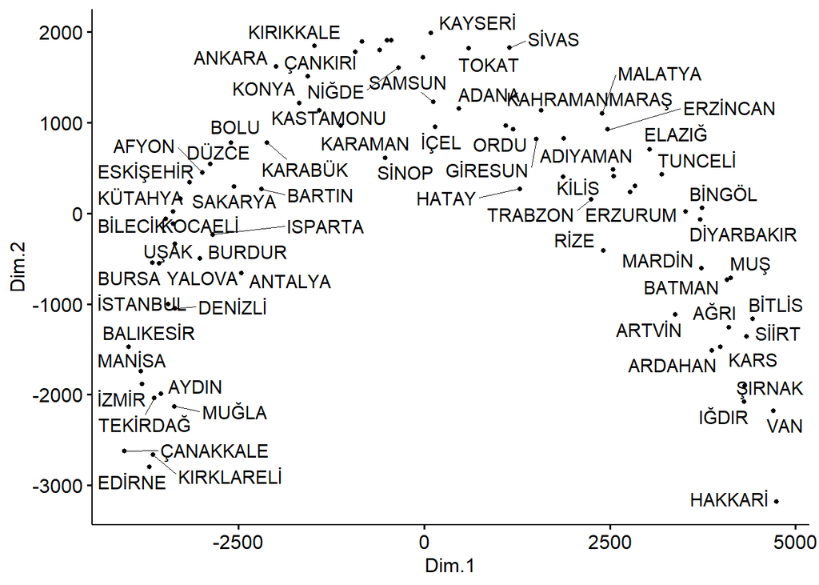

```r
mds <- distances %>%
  dist() %>%
  cmdscale() %>%
  as_tibble()
colnames(mds) <- c("Dim.1", "Dim.2")

ggscatter(mds, x = "Dim.1", y = "Dim.2",
          label = colnames(distances),
          size = 1,
          repel = TRUE)
```

It is expected that the cities closer to each other in Turkey’s map should be closer to each other in the graph as well. For instance, Ankara and Konya are closer to each other in the graph. Similarly, İstanbul, Bursa, Yalova, Denizli are closer to each other. We can see that the cities in each geographical region are clustered in the graph.

# Question 2

## Importing the Netflix and movies data

```r
movies <- read.delim(file= "C:/Users/Gaye/Desktop/ETM58D - Business Analytics/HW2_q2_movie_titles.txt", header = FALSE, sep = ",")
movies <- t(movies)
View(movies)

ratings <- read.delim(file= "C:/Users/Gaye/Desktop/ETM58D - Business Analytics/HW2_q2_Netflix_data.dat", header = FALSE, sep = " ")
NetflixRatings <- ratings %>%
    select_if(~ !any(is.na(.)))
NetflixRatings <- NetflixRatings %>%
  add_column(NetflixRatings[,100])
NetflixRatings <- NetflixRatings %>%
  add_column(NetflixRatings[,101])
View(NetflixRatings)

MovieRating <- rbind(movies[2,], NetflixRatings)
MovieRating[is.na(MovieRating)]=0
View(MovieRating)
```

```r
MovieRating <- MovieRating %>%
   filter_all(any_vars(is.na(.)))
mds1 <- MovieRating %>%
  dist() %>%
  cmdscale(.,k=5) %>%
  as_tibble()
colnames(mds1) <- c("Dim.1", "Dim.2")

ggscatter(mds1, x = "Dim.1", y = "Dim.2",
          label = colnames(MovieRating),
          size = 1,
          repel = TRUE)
```

[output not shown]

# Question 3

The plots were drawn but I could not take it to HTML report, due to some errors. The comments were written based on the plots for the first part of the question.

## Importing the data

```r
trainX <- read.delim(file= "C:/Users/Gaye/Desktop/ETM58D - Business Analytics/uWaveGestureLibrary_X_TRAIN.txt", header = FALSE, sep = " ")
View(trainX)

trainY <- read.delim(file= "C:/Users/Gaye/Desktop/ETM58D - Business Analytics/uWaveGestureLibrary_Y_TRAIN.txt", header = FALSE, sep = " ")
View(trainY)

trainZ <- read.delim(file= "C:/Users/Gaye/Desktop/ETM58D - Business Analytics/uWaveGestureLibrary_Z_TRAIN.txt", header = FALSE, sep = " ")
View(trainZ)
```

## Visualization of trainX data

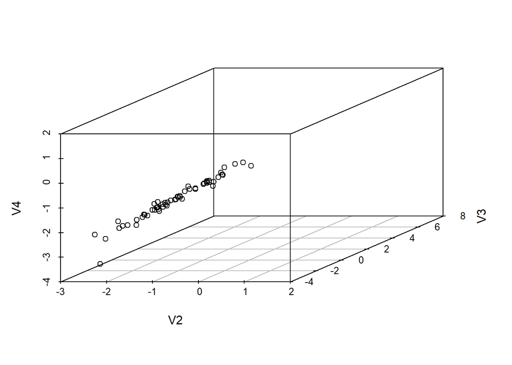

```r
plot_X1 <- scatterplot3d(trainX[,2:4])
```

```r
plot_X1
```

[output not shown]

[output cut: 114 more lines]

[output not shown]

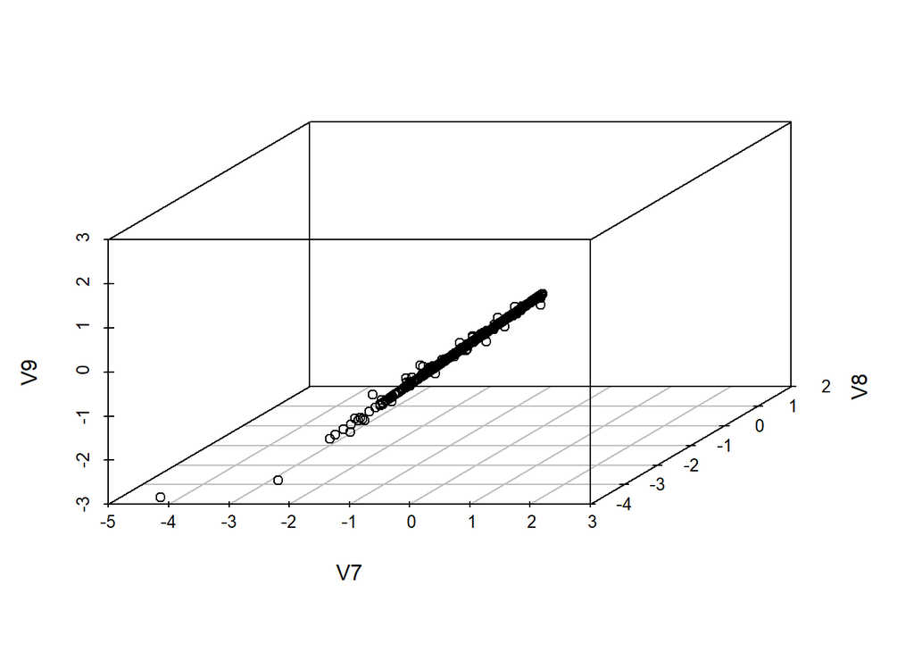

```r
plot_X2 <- scatterplot3d(trainX[,7:9])
```

```r
plot_X2
```

[output not shown]

[output cut: 114 more lines]

[output not shown]

## Visualization of trainY data

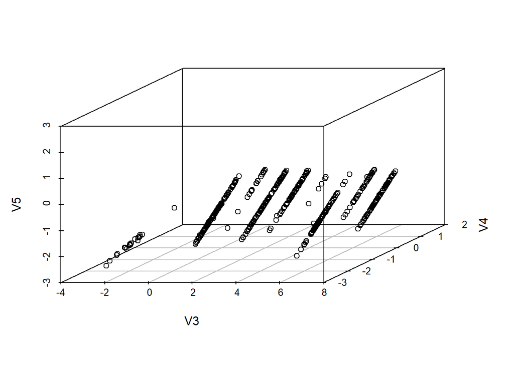

```r
plot_Y1 <- scatterplot3d(trainY[,3:5])
```

```r
plot_Y1
```

[output not shown]

[output cut: 114 more lines]

[output not shown]

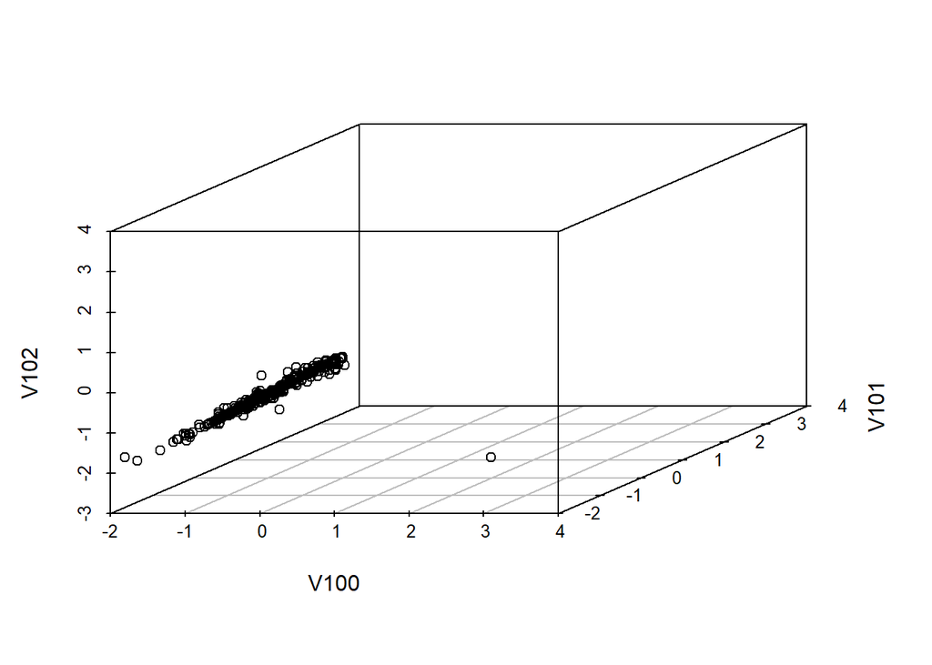

```r
plot_Y2 <- scatterplot3d(trainY[,100:102])
```

```r
plot_Y2
```

[output not shown]

[output cut: 114 more lines]

[output not shown]

3D scatter plot for train Y data is shown above. Some other instances were also tried and it is seen that the data is similar to the arrow showing the top (shape 5). Although the data in the first plot is diffused, they follow the 5-th shape in each cluster.

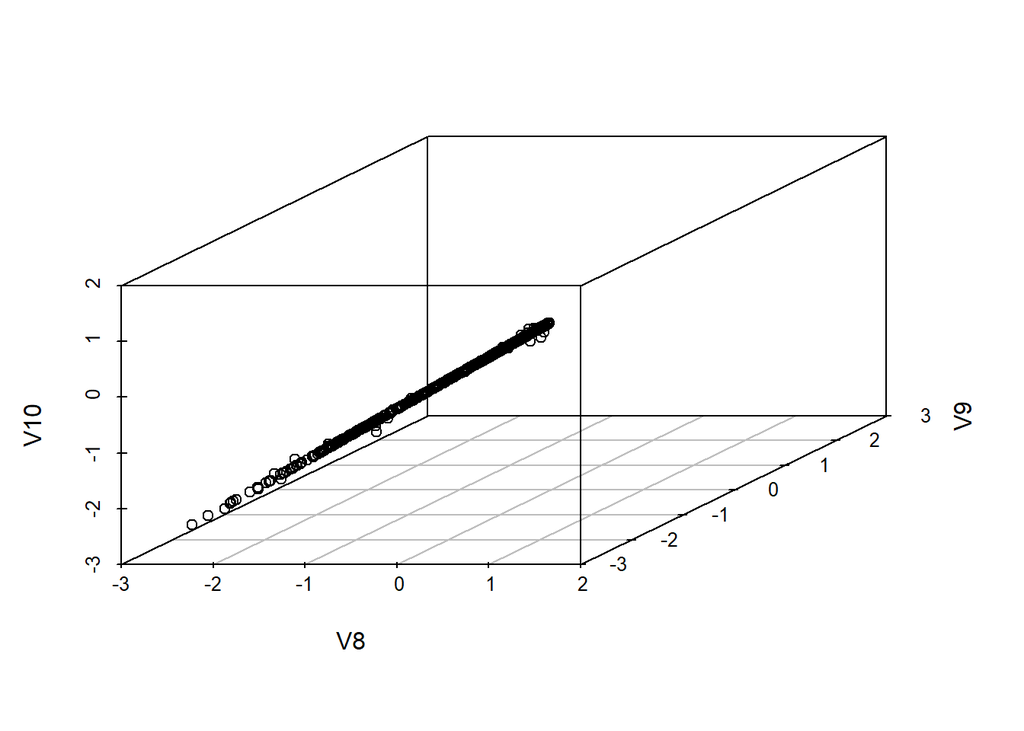

```r
plot_Z1 <- scatterplot3d(trainZ[,8:10])
```

```r
plot_Z1
```

[output not shown]

[output cut: 114 more lines]

[output not shown]

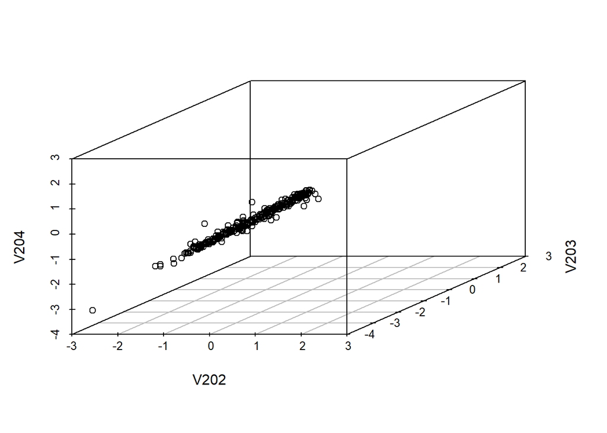

```r
plot_Z2 <- scatterplot3d(trainZ[,202:204])
```

```r
plot_Z2
```

[output not shown]

[output cut: 114 more lines]

[output not shown]

The trainZ data also shows a similar shape with trainX and trainY data. The gesture figure for trainZ data is shape 3.

## Concatenation of X,Y,Z data

```r
train_all <- cbind(trainX[1:941,], trainY[1:941,], trainZ[1:941,])
View(train_all)
```

```r
ggplot(train_all, aes(x=train_all[1,]))+
  geom_point(size=6)
```

[output not shown]